# Landuse Toolbox Data Exploration

This R Markdown aims at transparently exploring options to calculate crop-specific physical areas from Landuse Toolbox data.

# Calculate options

The following four options are discussed

| – | irrigation sys not differentiated | irrigation sys differentiated |
| --- | --- | --- |
| perennials not differentiated | (1a) | (1b) |
| perennials differentiated | (2a) | (2b) |

```r
## loading and baisc data setup
library(mrland)
library(scales)
library(tidyverse)
percent <- label_percent(accuracy = 0.001)

# read the data
harvestedArea <- readSource("LanduseToolbox", "harvestedArea")
physicalArea <- readSource("LanduseToolbox", "physicalArea")

#also read fallow land for conistency check
fallowArea <- calcOutput("FallowLand", aggregate = FALSE)

#extract some years to make everything faster
harvestedArea <- harvestedArea[, c("y1985","y2000", "y2015") ,]
physicalArea <-  physicalArea[, c("y1985", "y2000", "y2015") ,]
fallowArea <-  fallowArea[, c("y1985", "y2000", "y2015") ,]

#get rid of noncrops
non_crops <- c("pasture", "begr", "betr")
harvestedArea <- harvestedArea[, , non_crops, invert=T ]

# remove irrigation differentiation
harvestedAreaSum <- dimSums(harvestedArea, dim ="irrigation")
physicalAreaSum <-  dimSums(physicalArea, dim ="irrigation")
```

# (1a)

In a first attempt to calculate crop specific physical areas, we have no special treatments of perennials, nor separation of irrigation systems. Thus, we only calculate one (inverse multicropping) factor for each cell. We then make sure that crop specific land always fits into total physical land, by scaling down crop specific harvested area by this factor if necessary.

The below code chunk calculates the factor and prints out a summary

```r
# calculate physical crop specific areas of option (1a)

harvestedAreaSumTotal <- dimSums( harvestedAreaSum, dim = "crop")

factor_1a <- ifelse( harvestedAreaSumTotal != 0,
                   (physicalAreaSum / harvestedAreaSumTotal),
                   1 )
```

The below code chunk calculates the crop specific physical areas as described.

```r
# we only wan to scale down to keep fallow land, so it is conditioned on factor_1a<1
physicalOut_1a <- ifelse( factor_1a<1, harvestedArea * factor_1a, harvestedArea )

getSets(physicalOut_1a)["d3.1"]   <- "irrigation"
getSets(physicalOut_1a)["d3.2"]   <- "crop"
```

The relative change of total cropland of the year 2000 is

```r
totalbefore<-  sum(harvestedArea[,"y2000", ])
totalafter <-  sum(physicalOut_1a[,"y2000", ])

print( percent( (totalafter - totalbefore) / totalbefore )  )
```

```
## [1] "-10.440%"
```

Separately for irrigated and rainfed systems the relative change is

```r
totalbefore_rainfed <-  sum(harvestedArea[,"y2000", "rainfed" ])
totalafter_rainfed <-  sum(physicalOut_1a[,"y2000",  "rainfed" ])

totalbefore_irrigation <-  sum(harvestedArea[,"y2000","irrigated" ])
totalafter_irrigation <-  sum(physicalOut_1a[,"y2000", "irrigated"  ])

cat( "Irrigated area is reduced by:",
     percent( (totalafter_irrigation - totalbefore_irrigation) / totalbefore_irrigation ), "\n"  )
```

```
## Irrigated area is reduced by: -23.615%
```

```r
cat( "Rainfed area is reduced by:",
     percent( (totalafter_rainfed - totalbefore_rainfed) / totalbefore_rainfed )  )
```

```
## Rainfed area is reduced by: -6.628%
```

Check consitency with fallow land

```r
physical1 <-  dimSums( physicalOut_1a, dim=c("crop", "irrigation") )  + fallowArea

!any( abs(physical1 - physicalAreaSum)> 0.0000000000000001 )
```

```
## [1] TRUE
```

# (2a)

Next, we do treat perennials differently, but still refrain from seperating irrigation systems. More specifically, we take into account the fact that perennials are only harvested once a year, so that their physical area equals harvested area and the other crops must share the remaining physical area. We hope that sum of crop specific physical land will still fit into total physical land as a result.

```r
    perennials <- c("sugr_cane", "oilpalm")

    perennialHarvestedA <-  dimSums(harvestedAreaSum[, , perennials], dim = c("crop"))
    annualsHarvestedA <- dimSums(harvestedAreaSum[, , perennials, invert=T], dim = c("crop"))

    # check how  much physical area is remaining for the annualss after substracting the perennial physical area
    annualsPhysicalA <- physicalAreaSum - perennialHarvestedA # we can do that since for perennial physical=harvested

    # calculate a factor_2a by which the annuals should be scaled down so the sum does not exceed annualsPhysicalA
    factor_2a <- ifelse( annualsHarvestedA >0 ,annualsPhysicalA / annualsHarvestedA, 1)

    factor_2a[factor_2a <0] <- 0

    factor_2a[factor_2a >1] <- 1

    #apply the factor_2a if necessary to the annuals
    physicalOut_2a <- harvestedArea
    physicalOut_2a <- ifelse( factor_2a <1 & factor_2a >=0,  harvestedArea * factor_2a, harvestedArea )
    physicalOut_2a[ , , perennials] <-  harvestedArea[ , , perennials]

    #name dimensions
    getSets(physicalOut_2a)["d3.1"]   <- "irrigation"
    getSets(physicalOut_2a)["d3.2"]   <- "crop"
```

We have reduced total cropland of the year 2000 by

```r
totalbefore<-  sum(harvestedArea[,"y2000", ])
totalafter <-  sum(physicalOut_2a[,"y2000", ])

print( percent( (totalafter - totalbefore) / totalbefore )  )
```

```
## [1] "-10.434%"
```

Separately for irrigated and rainfed systems the relative change is

```r
totalbefore_rainfed <-  sum(harvestedArea[,"y2000", "rainfed" ])
totalafter_rainfed <-  sum(physicalOut_2a[,"y2000",  "rainfed" ])

totalbefore_irrigation <-  sum(harvestedArea[,"y2000","irrigated" ])
totalafter_irrigation <-  sum(physicalOut_2a[,"y2000", "irrigated"  ])

cat( "Irrigated area is reduced by:",
     percent( (totalafter_irrigation - totalbefore_irrigation) / totalbefore_irrigation ), "\n"  )
```

```
## Irrigated area is reduced by: -23.490%
```

```r
cat( "Rainfed area is reduced by:",
     percent( (totalafter_rainfed - totalbefore_rainfed) / totalbefore_rainfed )  )
```

```
## Rainfed area is reduced by: -6.655%
```

Note that we reduced total cropland a bit less than for option (1a). The reason behind this is that for some cells even completly zeroing the annuals is not enough to get down to physical area.

We can output the percentage of problematic cells by checking for physical area remaining for annuals being negative:

```r
percent(mean(annualsPhysicalA <0))
```

```
## [1] "0.023%"
```

## (1b)

Now calculate the irrigation specific but not perennial specific treatment. Crop and irrigation specific areas are reduced to fit into irrigated and rainfed cropland separately.

Calculate two reduction factors for each cell.

```r
# calculate physical crop specific areas of option (1b)

harvestedAreaTotal <- dimSums( harvestedArea, dim = "crop")

factor_1b <- ifelse( harvestedAreaTotal != 0,
                   physicalArea / harvestedAreaTotal,
                   1 )

#physicalOut_1b <- ifelse( factor_1b<1, harvestedArea * factor_1b, harvestedArea ) #not working as expected
```

The below code chunk calculates the crop specific physical areas as described.

```r
physicalRainfed <- ifelse( factor_1b[, , "rainfed"]<1, harvestedArea[ , , "rainfed"] * factor_1b[, , "rainfed"] ,
                       harvestedArea[ , , "rainfed"] )


physicalIrrigated <- ifelse( factor_1b[, , "irrigated"]<1, harvestedArea[ , , "irrigated"] * factor_1b[, , "irrigated"] ,
                         harvestedArea[ , , "irrigated"] )

physicalOut_1b <- mbind(physicalRainfed, physicalIrrigated  )

getSets(physicalOut_1b)["d3.1"]   <- "irrigation"
getSets(physicalOut_1b)["d3.2"]   <- "crop"
```

We have reduced total cropland of the year 2000 by

```r
totalbefore<-  sum(harvestedArea[,"y2000", ])
totalafter <-  sum(physicalOut_1b[,"y2000", ])

print( percent( (totalafter - totalbefore) / totalbefore )  )
```

```
## [1] "-11.478%"
```

Note that we reduced total cropland a bit more with this approach, which makes sense because we require not only the total (irrigation+rainfed) sum to be below physical area, but both irrigates and rainfed sums to be below the respective physical land separately. Let’s look at this reduction for irrigated and rainfed crops separately.

```r
totalbefore_rainfed <-  sum(harvestedArea[,"y2000", "rainfed" ])
totalafter_rainfed <-  sum(physicalOut_1b[,"y2000",  "rainfed" ])

totalbefore_irrigation <-  sum(harvestedArea[,"y2000","irrigated" ])
totalafter_irrigation <-  sum(physicalOut_1b[,"y2000", "irrigated"  ])

cat( "Irrigated area is reduced by:",
     percent( (totalafter_irrigation - totalbefore_irrigation) / totalbefore_irrigation ), "\n"  )
```

```
## Irrigated area is reduced by: -29.089%
```

```r
cat( "Rainfed area is reduced by:",
     percent( (totalafter_rainfed - totalbefore_rainfed) / totalbefore_rainfed )  )
```

```
## Rainfed area is reduced by: -6.382%
```

Note that irrigated area is reduced more and rainfed a bit less with this approach compared to 1a.

## (2b)

Finally we treat both, irrigation system and perennials, separately.

Thus we calculate two reduction factors for each cell.

```r
perennials <- c("sugr_cane", "oilpalm")

perennialHarvestedA_sep <-  dimSums(harvestedArea[, , perennials], dim = c("crop"))
annualsHarvestedA_sep <- dimSums(harvestedArea[, , perennials, invert=T], dim = c("crop"))

# check how  much physical area is remaining for the annualss after substracting the perennial physical area
annualsPhysicalA_sep <- physicalArea - perennialHarvestedA_sep # we can do that since for perennial physical=harvested

# calculate a factor by which the annuals should be scaled down so the sum does not exceed annualsPhysicalA_sep
factor_2b <- ifelse( annualsHarvestedA_sep >0 ,
                     annualsPhysicalA_sep / annualsHarvestedA_sep,
                     1)
factor_2b[ factor_2b<0 ] <- 0

#apply the factor_2b to the rainfed annuals
physicalRainfed <- harvestedArea[ , , "rainfed"]
physicalRainfed <- ifelse( factor_2b[,,"rainfed"] <1,
                           harvestedArea[ , , "rainfed"] * factor_2b[,,"rainfed"],
                           harvestedArea[ , , "rainfed"] )
physicalRainfed[ , , perennials] <-  harvestedArea[ , , "rainfed"][ , , perennials]

#apply to irrigated annuals
physicalIrrigated<- harvestedArea[ , , "irrigated"]
physicalIrrigated <- ifelse( factor_2b[,,"irrigated"] <1 ,
                           harvestedArea[ , , "irrigated"] *factor_2b[,,"irrigated"], harvestedArea[ , , "irrigated"] )
physicalIrrigated[ , , perennials] <-  harvestedArea[ , , "irrigated"][ , , perennials]

physicalOut_2b <- mbind(physicalRainfed, physicalIrrigated)

#name dimensions
getSets(physicalOut_2b)["d3.1"]   <- "irrigation"
getSets(physicalOut_2b)["d3.2"]   <- "crop"
```

We have reduced total cropland of the year 2000 by

```r
totalbefore<-  sum(harvestedArea[,"y2000", ])
totalafter <-  sum(physicalOut_2b[,"y2000", ])

print(  percent( (totalafter - totalbefore) / totalbefore )  )
```

```
## [1] "-11.455%"
```

This is again a bit less then above due to mismatches.

```r
totalbefore_rainfed <-  sum(harvestedArea[,"y2000", "rainfed" ])
totalafter_rainfed <-  sum(physicalOut_2b[,"y2000",  "rainfed" ])

totalbefore_irrigation <-  sum(harvestedArea[,"y2000","irrigated" ])
totalafter_irrigation <-  sum(physicalOut_2b[,"y2000", "irrigated"  ])

cat( "Irrigated area is reduced by:",
     percent( (totalafter_irrigation - totalbefore_irrigation) / totalbefore_irrigation ), "\n"  )
```

```
## Irrigated area is reduced by: -29.003%
```

```r
cat( "Rainfed area is reduced by:",
     percent( (totalafter_rainfed - totalbefore_rainfed) / totalbefore_rainfed )  )
```

```
## Rainfed area is reduced by: -6.377%
```

Again we cannot always reduce as much as we want when leaving the perennials untouched.

Percentage of cells were zeroing rainfed annuals is not enough to get down to physical rainfed:

```r
percent(mean(annualsPhysicalA_sep[ , ,"rainfed"] <0))
```

```
## [1] "0.124%"
```

Percentage of cells were zeroing irrigated annuals is not enough to get down to physical irrigated:

```r
percent(mean(annualsPhysicalA_sep[ , ,"irrigated"] <0))
```

```
## [1] "0.074%"
```

On average the procedure to get down to physical area (both irrigated and rainfed) by reducing annuals fails in

```r
percent(mean(annualsPhysicalA_sep <0))
```

```
## [1] "0.099%"
```

of cases.

# Compare Options

## Compare (1a) and (2a)

### Perennial area change

First compare perennial areas of option (1a) and (2a)

```r
perSum_1 <- dimSums(physicalOut_1a[ , , perennials], dim = c("crop", "irrigation"))
perSum_2 <- dimSums(physicalOut_2a[ , , perennials], dim = c("crop", "irrigation"))

# How much do we reduce perennias with the first appoach?
per_change <- perSum_1- perSum_2

#In relative terms
per_change_rel <- ifelse( perSum_2>0 , per_change/ perSum_2, 0 )

print("absolute change:")
```

```
## [1] "absolute change:"
```

```r
summary(per_change)
```

```
##       Min.    1st Qu.     Median       Mean    3rd Qu.       Max.
## -9.779e-02  0.000e+00  0.000e+00 -7.328e-05  0.000e+00  0.000e+00
```

```r
print("realtive change:")
```

```
## [1] "realtive change:"
```

```r
summary(per_change_rel)
```

```
##     Min.  1st Qu.   Median     Mean  3rd Qu.     Max.
## -0.66665  0.00000  0.00000 -0.01983  0.00000  0.00000
```

#### Year 2000

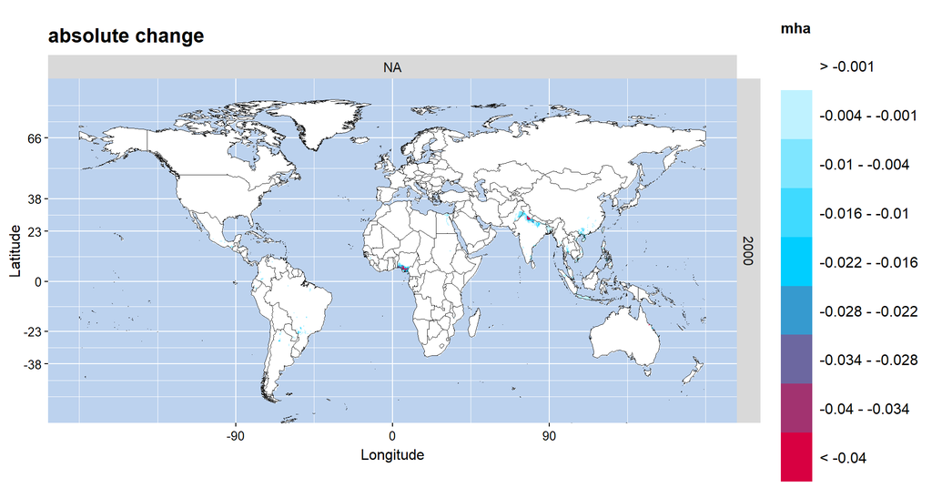

```r
library(ggplot2)


luplot::plotmap2( toolCoord2Isocell(
  per_change[,"y2000",] )  ,
legend_range = c(-0.09,0 ) , legend_discrete =T, legend_breaks= c(seq(-0.04,0.000,0.006), -0.001),
highcol = "#FFFFFF",
lowcol = "#d80041",
midcol = "#00ceff",
title = "absolute change",
legendname = "mha",
midpoint=0 ) + theme(legend.key.size = unit(0.9, 'cm'), legend.key.height = unit(1.4, 'cm'))
```

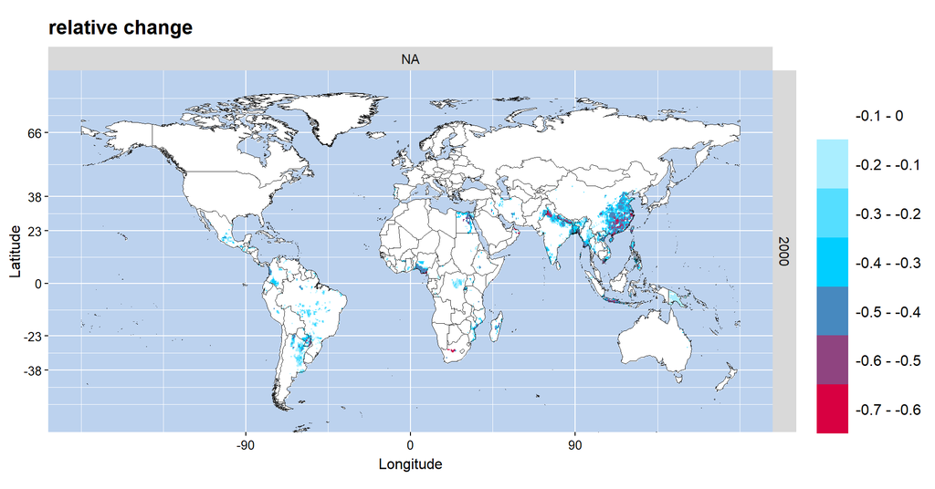

```r
luplot::plotmap2( toolCoord2Isocell(
  per_change_rel[,"y2000",] )  ,
  legend_range = c(-1,0 ) , legend_discrete =T, legend_breaks= c(seq(-1,0,0.1)),
  highcol = "#FFFFFF",
  lowcol = "#d80041",
  midcol = "#00ceff",
  legendname = "",
  title = "relative change",
  midpoint=0 ) + theme(legend.key.size = unit(0.9, 'cm'), legend.key.height = unit(1.4, 'cm'))
```

#### Year 1985

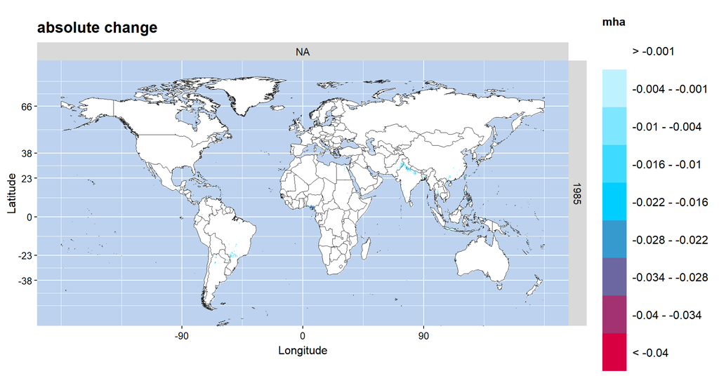

```r
luplot::plotmap2( toolCoord2Isocell(
  per_change[,"y1985",] )  ,
  legend_range = c(-0.09,0 ) , legend_discrete =T, legend_breaks= c(seq(-0.04,0.000,0.006), -0.001),
  highcol = "#FFFFFF",
  lowcol = "#d80041",
  midcol = "#00ceff",
  title = "absolute change",
  legendname = "mha",
  midpoint=0 ) + theme(legend.key.size = unit(0.9, 'cm'), legend.key.height = unit(1.4, 'cm'))
```

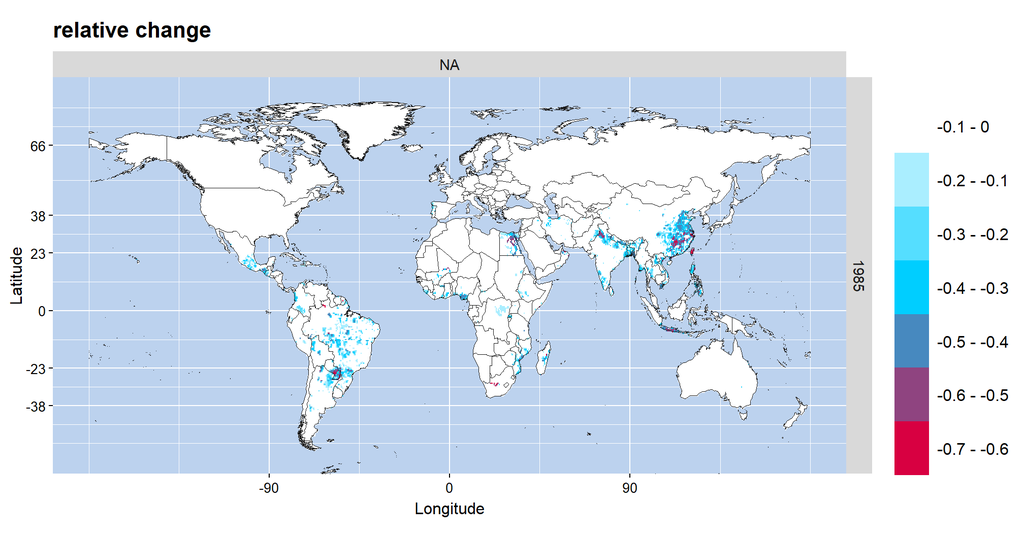

```r
luplot::plotmap2( toolCoord2Isocell(
  per_change_rel[,"y1985",] )  ,
  legend_range = c(-1,0 ) , legend_discrete =T, legend_breaks= c(seq(-1,0,0.1)),
  highcol = "#FFFFFF",
  lowcol = "#d80041",
  midcol = "#00ceff",
  legendname = "",
  title = "relative change",
  midpoint=0 ) + theme(legend.key.size = unit(0.9, 'cm'), legend.key.height = unit(1.4, 'cm'))
```

#### Year 2015

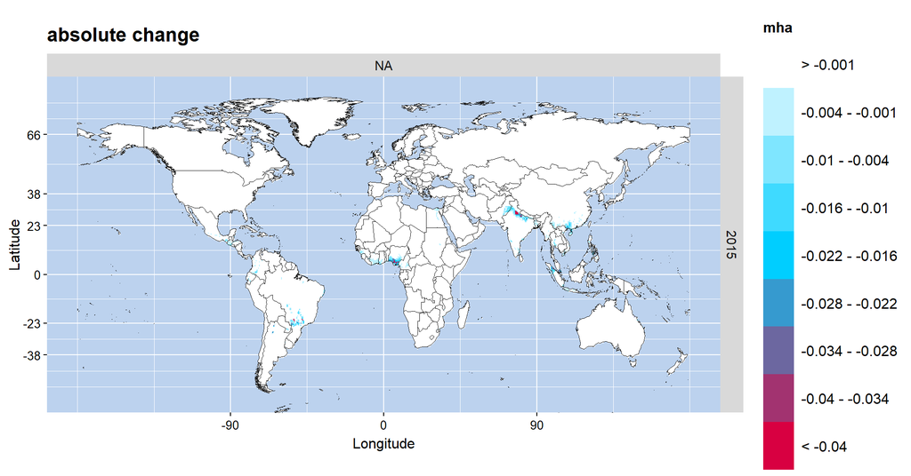

```r
luplot::plotmap2( toolCoord2Isocell(
  per_change[,"y2015",] )  ,
  legend_range = c(-0.09,0 ) , legend_discrete =T, legend_breaks= c(seq(-0.04,0.000,0.006), -0.001),
  highcol = "#FFFFFF",
  lowcol = "#d80041",
  midcol = "#00ceff",
  title = "absolute change",
  legendname = "mha",
  midpoint=0 ) + theme(legend.key.size = unit(0.9, 'cm'), legend.key.height = unit(1.4, 'cm'))
```

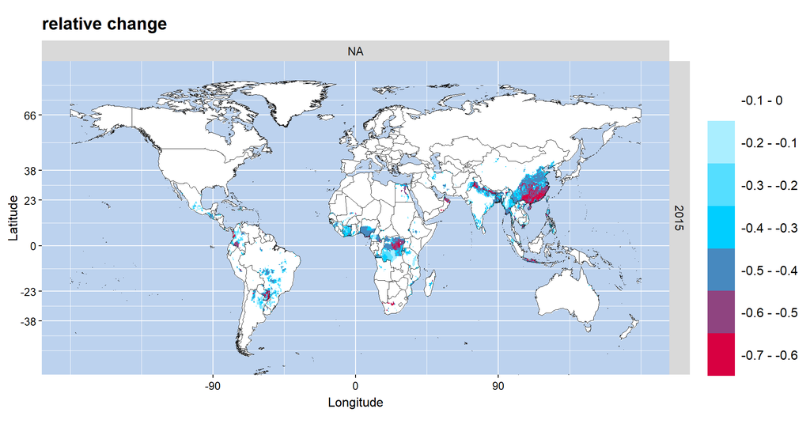

```r
luplot::plotmap2( toolCoord2Isocell(
  per_change_rel[,"y2015",] )  ,
  legend_range = c(-1,0 ) , legend_discrete =T, legend_breaks= c(seq(-1,0,0.1)),
  highcol = "#FFFFFF",
  lowcol = "#d80041",
  midcol = "#00ceff",
  legendname = "",
  title = "relative change",
  midpoint=0 ) + theme(legend.key.size = unit(0.9, 'cm'), legend.key.height = unit(1.4, 'cm'))
```

### Annuals cropping intensity

Now compare cropping intensity for annuals. We see cropping intensity here as a multicropping factor. It is the factor by which the physical area of a crop is multiplied in order to get harvested area.

Calculate CI annuals for (1a)

```r
CI_annuals1 <- pmax(dimSums(harvestedArea, dim=c("crop","irrigation")) / physicalAreaSum,1)

summary(CI_annuals1[,"y2000",])
```

```
##    Min. 1st Qu.  Median    Mean 3rd Qu.    Max.    NA's
##   1.000   1.000   1.000   1.052   1.000   2.996   28646
```

Calculate CI annuals for (2a)

```r
annualsPhysicalA<- toolConditionalReplace(annualsPhysicalA, "<0", 0)

CI_annuals2 <- pmax(annualsHarvestedA/ annualsPhysicalA,1)

summary(CI_annuals2[,"y2000",])
```

```
##    Min. 1st Qu.  Median    Mean 3rd Qu.    Max.    NA's
##       1       1       1     Inf       1     Inf   28646
```

Note that in R $\frac{0}{0} = NA$ and $\frac{a}{0} = Inf, for~ a>0$

#### Some sanity cheks for CIs of (2a) and (1a)

Check if CI_annuals2 as it is calculated above, is in fact equal to the multicropping factor for different annual crops where physical area is calculated with (2a).

```r
CI_annuals2_specific <-   harvestedArea/ physicalOut_2a


summary( abs(CI_annuals2_specific[,"y2000","rainfed.tece"] - CI_annuals2[,"y2000",]  )  )
```

```
##    Min. 1st Qu.  Median    Mean 3rd Qu.    Max.    NA's
##       0       0       0       0       0       0   33129
```

```r
summary( abs(CI_annuals2_specific[,"y2000","rainfed.soybean"] - CI_annuals2[,"y2000",]  )  )
```

```
##    Min. 1st Qu.  Median    Mean 3rd Qu.    Max.    NA's
##       0       0       0       0       0       0   41206
```

```r
summary( abs(CI_annuals2_specific[,"y2000","irrigated.maiz"] - CI_annuals2[,"y2000",] )  )
```

```
##    Min. 1st Qu.  Median    Mean 3rd Qu.    Max.    NA's
##       0       0       0       0       0       0   59636
```

```r
summary( abs(CI_annuals2_specific[,"y2000","irrigated.foddr"] - CI_annuals2[,"y2000",] )  )
```

```
##    Min. 1st Qu.  Median    Mean 3rd Qu.    Max.    NA's
##       0       0       0       0       0       0   60752
```

On the other hand CI_annuals2 should not be equal to the multicropping factor of perennials.

```r
summary( abs(CI_annuals2_specific[,"y2000","rainfed.sugr_cane"] - CI_annuals2[,"y2000",] )  )
```

```
##    Min. 1st Qu.  Median    Mean 3rd Qu.    Max.    NA's
##       0       0       0     Inf       0     Inf   51201
```

Instead in the (2a) approach the multicropping factor of perennials should be 1. Let’s confirm this.

```r
summary(CI_annuals2_specific[,"y2000","irrigated.sugr_cane"])
```

```
##    Min. 1st Qu.  Median    Mean 3rd Qu.    Max.    NA's
##       1       1       1       1       1       1   62740
```

```r
summary(CI_annuals2_specific[,"y2000","rainfed.sugr_cane"])
```

```
##    Min. 1st Qu.  Median    Mean 3rd Qu.    Max.    NA's
##       1       1       1       1       1       1   51201
```

```r
summary(CI_annuals2_specific[,"y2000","rainfed.oilpalm"])
```

```
##    Min. 1st Qu.  Median    Mean 3rd Qu.    Max.    NA's
##       1       1       1       1       1       1   58277
```

The CI of annuals of approach 1a should be smaller or equal to the CI_annuals of 2a.

```r
!any(!CI_annuals1<=CI_annuals2+ 10^-12, na.rm = T)
```

```
## [1] TRUE
```

For 1a the CI_annuals1 calculated above should be equal to the actual CI of any crop (including perennials) with physical area calculated with 1a.

```r
CI_annuals1_specific <-   harvestedArea/ physicalOut_1a


summary( abs(CI_annuals1_specific[,"y2000","rainfed.tece"] - CI_annuals1[,"y2000",]  )  )
```

```
##    Min. 1st Qu.  Median    Mean 3rd Qu.    Max.    NA's
##       0       0       0       0       0       0   33120
```

```r
summary( abs(CI_annuals1_specific[,"y2000","rainfed.soybean"] - CI_annuals1[,"y2000",]  )  )
```

```
##    Min. 1st Qu.  Median    Mean 3rd Qu.    Max.    NA's
##       0       0       0       0       0       0   41202
```

```r
summary( abs(CI_annuals1_specific[,"y2000","irrigated.maiz"] - CI_annuals1[,"y2000",] )  )
```

```
##    Min. 1st Qu.  Median    Mean 3rd Qu.    Max.    NA's
##       0       0       0       0       0       0   59632
```

```r
summary( abs(CI_annuals1_specific[,"y2000","irrigated.foddr"] - CI_annuals1[,"y2000",] )  )
```

```
##    Min. 1st Qu.  Median    Mean 3rd Qu.    Max.    NA's
##       0       0       0       0       0       0   60749
```

```r
summary( abs(CI_annuals1_specific[,"y2000","rainfed.sugr_cane"] - CI_annuals1[,"y2000",] )  )
```

```
##    Min. 1st Qu.  Median    Mean 3rd Qu.    Max.    NA's
##       0       0       0       0       0       0   51201
```

It would be reasonable to assume that nothing can be harvested, if we have no physical cropping area.

```r
!any(harvestedAreaSumTotal>0 & physicalAreaSum ==0)
```

```
## [1] TRUE
```

#### Compare via histograms

##### Year 2000

One worry with choosing the second approach is that we get very high cropping intensities for the annuals when preallocating perennial area to physical cropland. The following histograms investigate whether existence of perennials in cells can drive up the CIs for the annuals.

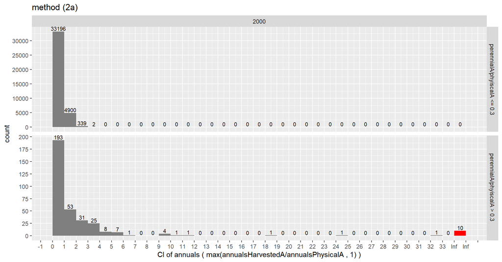

```r
library(tidyverse)

DF_per <- as.data.frame(perennialHarvestedA)

DF_per %<>% mutate(perennialHA = Value ) %>% select(perennialHA)

DF_physical <- as.data.frame( physicalAreaSum )

DF_physical %<>% mutate(physicalTOT = Value ) %>% select(physicalTOT)

DF2<-as.data.frame(CI_annuals2) %>% mutate(multi2 =Value) %>% select(multi2, Year)

DF1<-as.data.frame(CI_annuals1) %>% mutate(multi1 =Value) %>% select(multi1)

DF_bind <- cbind(DF2,DF_per,DF1, DF_physical)

# DF_bind %>%
#       mutate(CI_class = cut(multi2,breaks=c(seq(0,10,0.5), Inf ))) %>%
#       mutate(per_dom = perennialHA/physicalTOT >0.3) %>%
#       group_by(CI_class, Year, per_dom, .drop = FALSE) %>% summarise(count=n()) -> binnedCI

#
# ggplot( binnedCI %>% filter(Year =="2000"& per_dom), aes(x=CI_class , y= count)) +
#   geom_bar(stat="identity") +
#   scale_y_continuous(n.breaks = 15)+
#   geom_text(aes(label=count, vjust=-0.25))+
#   labs(x= "CI of annuals (annualsHarvestedA/annualsPhysicalA)", title =  "perennialA/physicalA>0.3")
#
# ggplot( binnedCI %>% filter(Year =="2000"& !per_dom), aes(x=CI_class , y= count)) +
#   geom_bar(stat="identity") +
#   scale_y_continuous(n.breaks = 15) +
#   geom_text(aes(label=count, vjust=-0.25))+
#   labs(x= "CI of annuals (annualsHarvestedA/annualsPhysicalA)", title =  "perennialA/physicalA<0.3")


hist_annualCI_multi <-  function( year, data, facet =T, titel = "CI", labx = "CI of annuals ( max(annualsHarvestedA/annualsPhysicalA , 1) )"){

  p<-
    ggplot( data %>% filter(Year== year, physicalTOT>0) %>% mutate(perenDOM = perennialHA/physicalTOT > 0.3,
                                                                    multi = case_when(multi==Inf ~ 35,
                                                                                         multi<Inf & multi >=33 ~ 34,
                                                                                         TRUE~ multi ) ) ,
          aes(x=multi ,  fill= case_when( multi == 35 ~ "A",multi == 34 ~ "B" ,TRUE ~ "C" )  )) +
    geom_histogram(breaks = seq(0,35,1) , show.legend = F ) +
    scale_y_continuous(n.breaks = 10 ) +
    scale_fill_manual(values = list( A= "red",B= "green", C="gray50" ) )+
    scale_x_continuous(n.breaks = 35, labels = c( as.character( seq(-1,33,1)), "Inf","Inf","" ) )+
    labs(x= labx, title = titel) +
    stat_bin(breaks = seq(0,35,1),aes(y=..count.., label=..count.., fill = NULL), size =2.9, geom="text", vjust=-0.25)

  if(facet==T){

     p<- p+ facet_grid( perenDOM~Year, scales = "free_y",
                labeller =  labeller( perenDOM = ~ifelse(.,"perennialA/phyiscalA > 0.3 ", " perennialA/phyiscalA <= 0.3 ") ) )
  }

  return(p)
}

hist_annualCI_multi( "2000", DF_bind %>% mutate(multi = multi2), titel = "method (2a)" )
```

Note the 10 inf values. Infinite values of annuals cropping intensity occur when there is no phyisical area left after allocation of perennial harvested area, but we do have existing annuals harvested area.

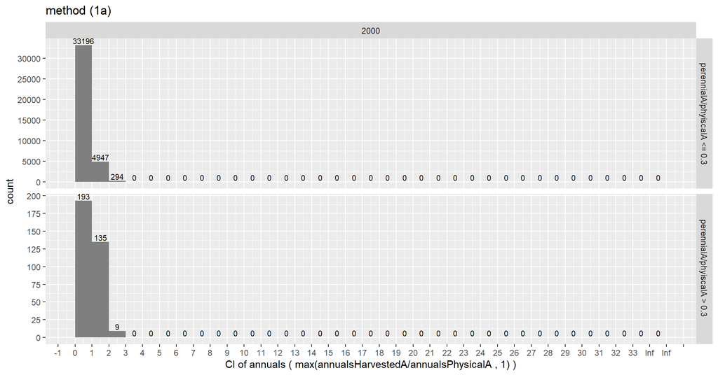

```r
hist_annualCI_multi( "2000", DF_bind %>% mutate(multi = multi1), titel = "method (1a)" )
```

##### Year 1985

Plot the same for 1985

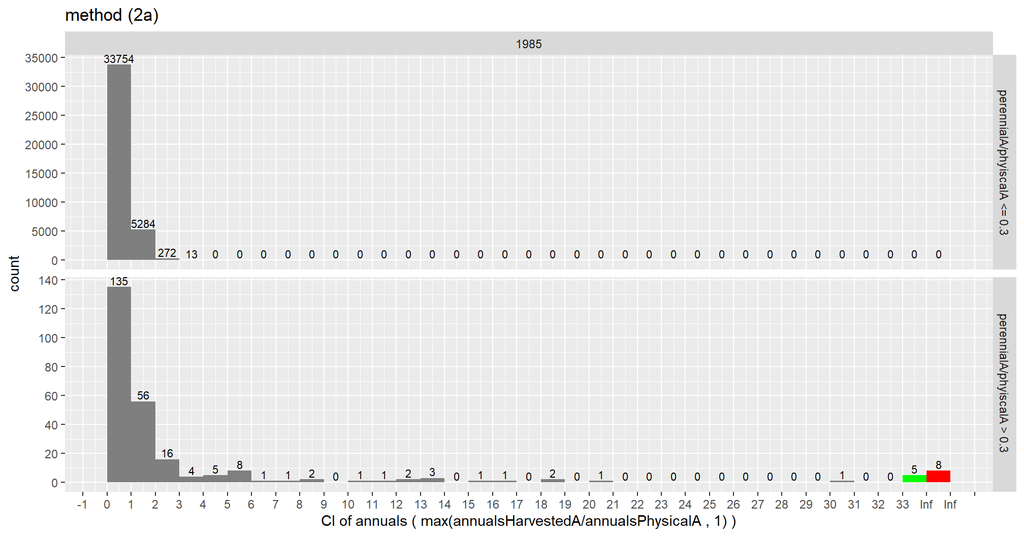

```r
hist_annualCI_multi( "1985", DF_bind %>% mutate(multi = multi2),  titel = "method (2a)" )
```

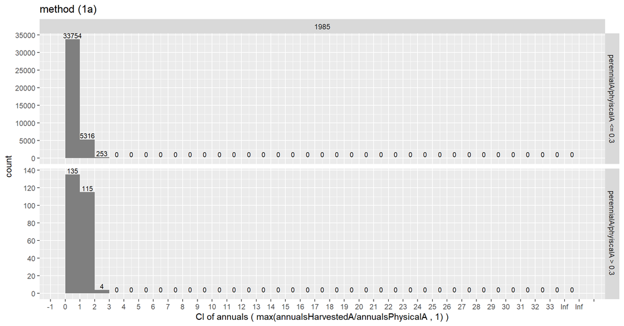

```r
hist_annualCI_multi( "1985", DF_bind %>% mutate(multi = multi1),  titel = "method (1a)" )
```

##### Year 2015

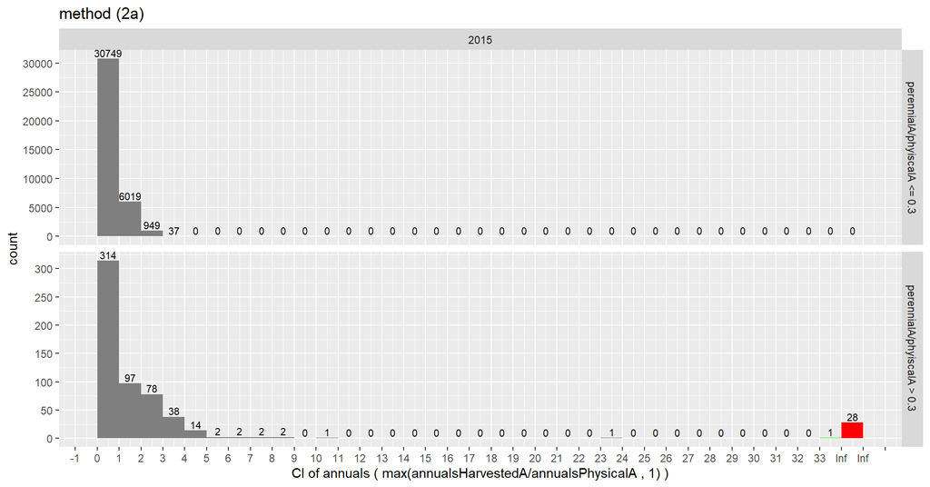

```r
hist_annualCI_multi( "2015", DF_bind %>% mutate(multi = multi2), titel = "method (2a)" )
```

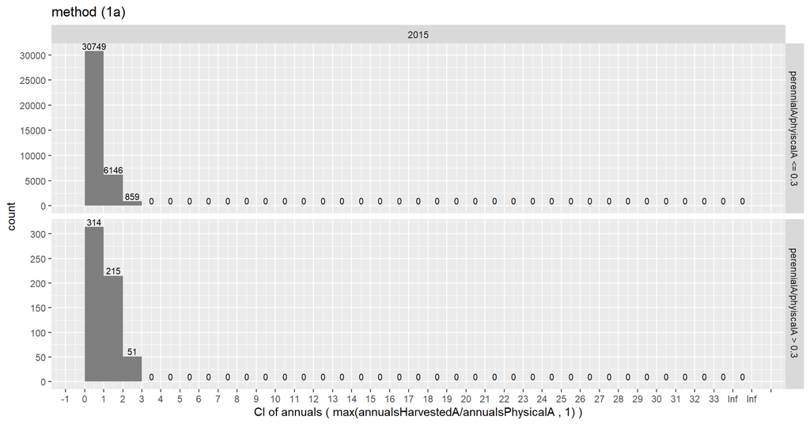

```r
hist_annualCI_multi( "2015", DF_bind %>% mutate(multi = multi1), titel = "method (1a)" )
```

#### CI_Annuals for “growing regions” of different crops

The previous comparison suggests that (2a) can result in unrealistically high CI_annuals for cells with some perennial share. To get a more detailed picture of where the problem occurs, compare CI_Annuals for regions where different crops grow.

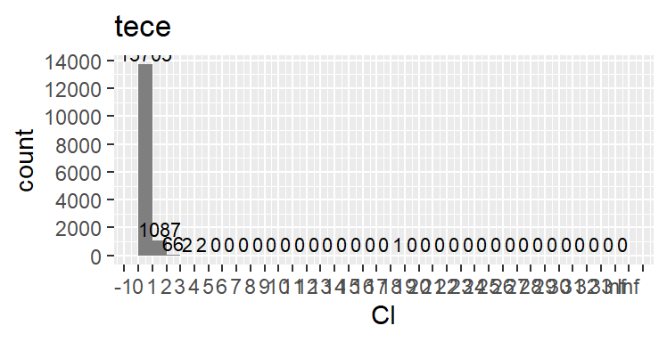

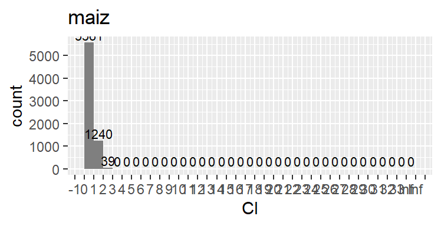

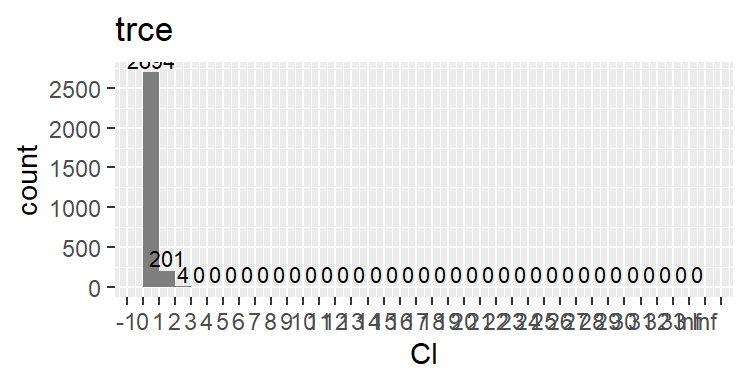

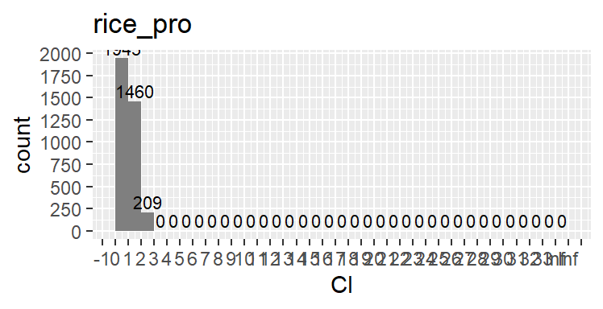

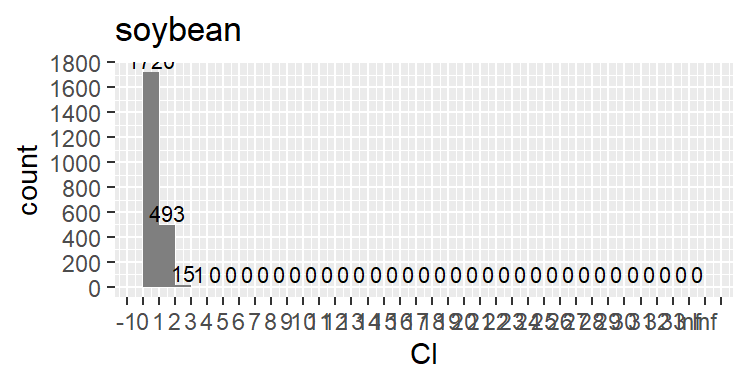

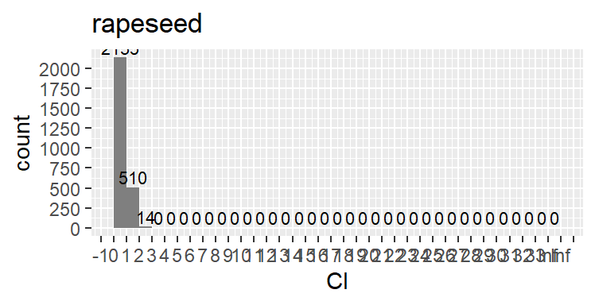

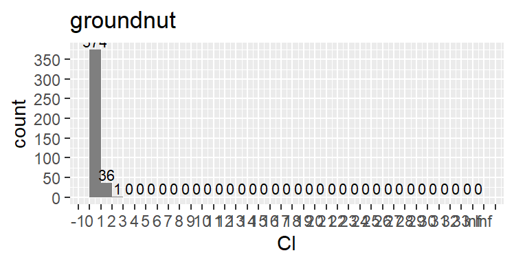

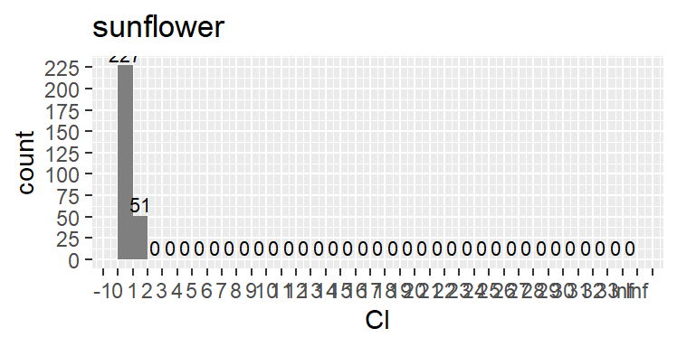

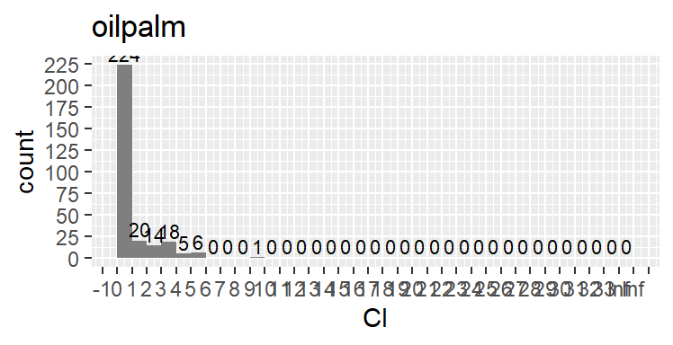

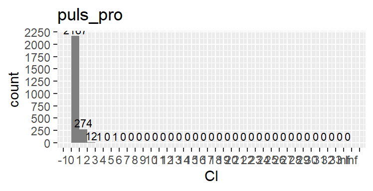

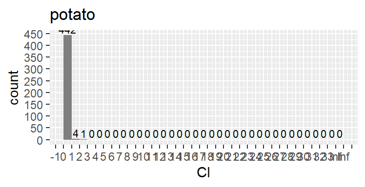

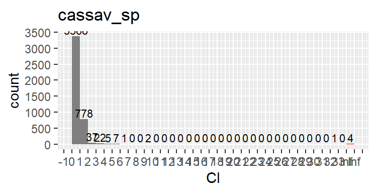

[5 more figures not shown]

```r
harvestedAreaShare <- harvestedAreaSum / harvestedAreaSumTotal

for(i in c(seq(1,17)) ){

year<- "y2000"
crop<- i
Cells_with_crop_i <- which(harvestedAreaShare[,year,crop] > 0.2 )
multi_crop<- CI_annuals2[Cells_with_crop_i,year]
DF_crop <- as.data.frame( multi_crop)

hist_annualCI_multi( "2000", DF_crop  %>% mutate(multi = Value, perennialHA = 1, physicalTOT =1) , facet =F,
                     titel= getItems(harvestedAreaShare)$crop[crop], labx = "CI" ) %>% print()


}
```

As expected we see high CI_annuals in cells where the annuals share physical area with sugar cane and oilpalm. Furthermore, we also get problematic CI_annuals in cells with some cassava share.

#### Plotting the difference $annualsCroppingIntensity2a - annualsCroppingIntensity1a$

Lets see on a map where CI_annuals for 2a is higher then for 1a.

##### Year 2000

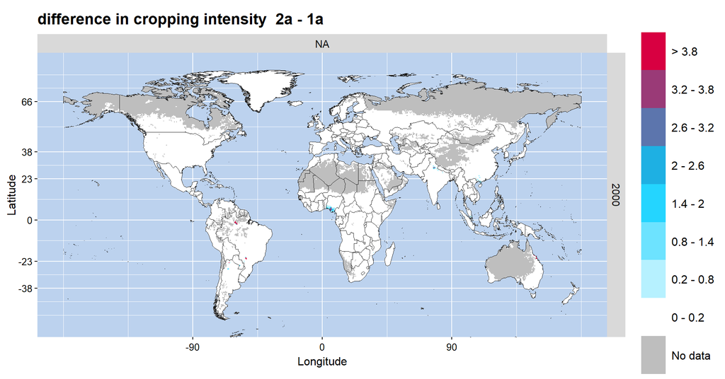

```r
multidiff <- CI_annuals2 - CI_annuals1

luplot::plotmap2( toolCoord2Isocell(
  multidiff[,"y2000",] )  ,
  legend_range = c(0,100 ) ,
  highcol = "#d80041", legend_discrete =T, legend_breaks= c(0,seq(0.2,4.3,0.6)),
  midcol = "#00ceff",
  lowcol = "#FFFFFF",
  title = "difference in cropping intensity  2a - 1a",
  legendname = "",
  midpoint=0 ) +
  theme(legend.key.size = unit(0.9, 'cm'), legend.key.height = unit(1.4, 'cm'))
```

#### Year 1985

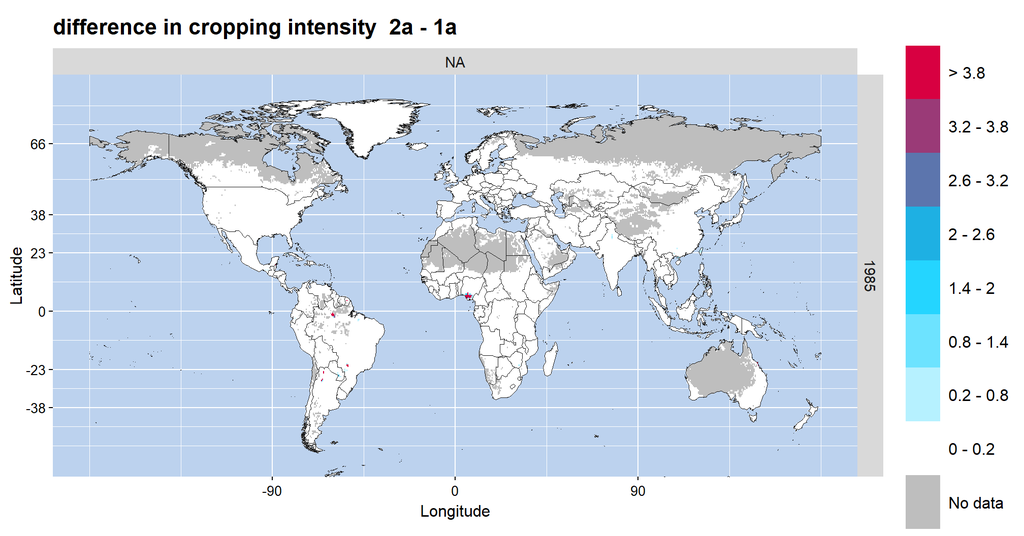

```r
luplot::plotmap2( toolCoord2Isocell(
  multidiff[,"y1985",] )  ,
  legend_range = c(0,100 ) ,
  highcol = "#d80041", legend_discrete =T, legend_breaks= c(0,seq(0.2,4.3,0.6)),
  midcol = "#00ceff",
  lowcol = "#FFFFFF",
  title = "difference in cropping intensity  2a - 1a",
  legendname = "",
  midpoint=0 )+
  theme(legend.key.size = unit(0.9, 'cm'), legend.key.height = unit(1.4, 'cm'))
```

##### Year 2015

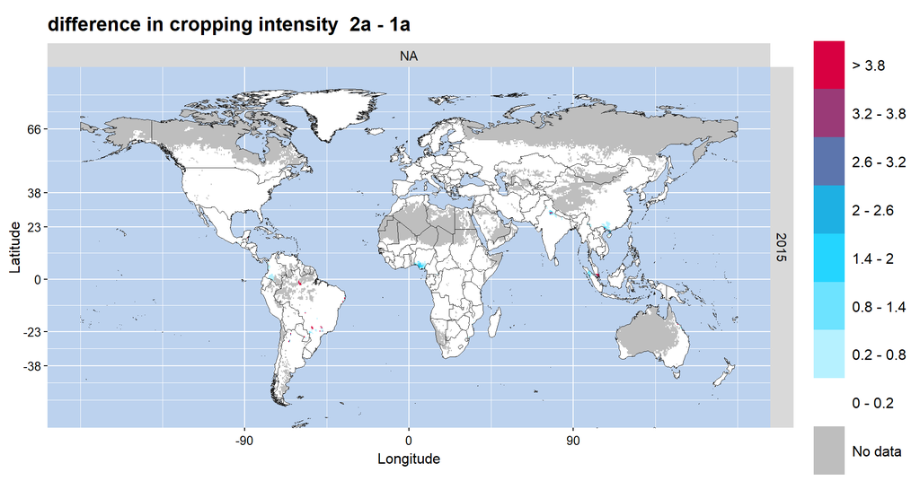

```r
luplot::plotmap2( toolCoord2Isocell(
  multidiff[,"y2015",] )  ,
  legend_range = c(0,100 ) ,
  highcol = "#d80041", legend_discrete =T, legend_breaks= c(0,seq(0.2,4.3,0.6)),
  midcol = "#00ceff",
  lowcol = "#FFFFFF",
  title = "difference in cropping intensity  2a - 1a",
  legendname = "",
  midpoint=0 )+
  theme(legend.key.size = unit(0.9, 'cm'), legend.key.height = unit(1.4, 'cm'))
```

## Compare a- with b-approaches

### Sanity checks

Calculate the irrigation specific multicropping factors for 1b in a crop specific and general way and see if both are equal.

```r
CI_1b_specific <- harvestedArea/physicalOut_1b

CI_1b_irri <- pmax( dimSums(harvestedArea[,, "irrigated"] , dim= "crop") / physicalArea[,, "irrigated"],1)
CI_1b_rain <- pmax( dimSums(harvestedArea[,, "rainfed"] , dim= "crop") / physicalArea[,, "rainfed"] ,1)

CI_1b <- mbind(CI_1b_irri,CI_1b_rain )


CI_1a <- pmax( harvestedAreaSumTotal/ physicalAreaSum,1)

summary( CI_1b_specific[,, "irrigated.rice_pro"]- CI_1b[,,"irrigated"])
```

```
##    Min. 1st Qu.  Median    Mean 3rd Qu.    Max.    NA's
##       0       0       0       0       0       0  180628
```

```r
summary( CI_1b_specific[,, "irrigated.oilpalm"]- CI_1b[,,"irrigated"])
```

```
##    Min. 1st Qu.  Median    Mean 3rd Qu.    Max.    NA's
##       0       0       0       0       0       0  202045
```

CIs for rainfed crops should not be equal general irrigated CI…

```r
summary( (CI_1b_specific[,, "rainfed.soybean"]- CI_1b[,, "irrigated"])/CI_1b_specific[,, "rainfed.rice_pro"] )
```

```
##    Min. 1st Qu.  Median    Mean 3rd Qu.    Max.    NA's
##   -2.00   -0.20    0.00   -0.12    0.00    1.00  191081
```

… but only general rainfed CI.

```r
summary( (CI_1b_specific[,, "rainfed.soybean"]- CI_1b[,, "rainfed"]) )
```

```
##    Min. 1st Qu.  Median    Mean 3rd Qu.    Max.    NA's
##    -0.5     0.0     0.0     0.0     0.0     0.5  122193
```

There is something off: Crop specific CI for rainfed.soybean is not equal to general rainfed CI.

The relative difference is zero on the other hand:

```r
summary( (CI_1b_specific[,, "rainfed.soybean"]- CI_1b[,, "rainfed"])/CI_1b[,, "rainfed"])
```

```
##    Min. 1st Qu.  Median    Mean 3rd Qu.    Max.    NA's
##       0       0       0       0       0       0  122193
```

```r
summary( (CI_1b_specific[,, "rainfed.rice_pro"]- CI_1b[,, "rainfed"])/CI_1b[,, "rainfed"])
```

```
##    Min. 1st Qu.  Median    Mean 3rd Qu.    Max.    NA's
##       0       0       0       0       0       0  148698
```

```r
summary( (CI_1b_specific[,, "rainfed.sugr_cane"]- CI_1b[,, "rainfed"])/CI_1b[,, "rainfed"])
```

```
##    Min. 1st Qu.  Median    Mean 3rd Qu.    Max.    NA's
##       0       0       0       0       0       0  152798
```

Further note that the corresponding CI values are extremely high

```r
Z <- which( abs(CI_1b_specific[,"y1985", "rainfed.soybean"]- CI_1b[,"y1985", "rainfed"])>10^-8)

summary(CI_1b[Z ,"y1985", "rainfed"] )
```

```
##      Min.   1st Qu.    Median      Mean   3rd Qu.      Max.
## 5.131e+14 1.693e+15 2.352e+15 2.156e+15 2.754e+15 3.320e+15
```

And that the respective physical is extremely small.

```r
summary(physicalArea[Z ,"y1985", "rainfed"] )
```

```
##      Min.   1st Qu.    Median      Mean   3rd Qu.      Max.
## 1.100e-23 5.596e-21 1.402e-19 1.806e-18 1.171e-18 2.272e-17
```

Dividing by such low numbers can magnify round off errors so that they become visible.

Note that for the respective cells the harvested areas are not so very low, which is why we get those very high CIs.

```r
summary(harvestedAreaTotal[Z,"y1985","rainfed"])
```

```
##      Min.   1st Qu.    Median      Mean   3rd Qu.      Max.
## 3.000e-08 1.325e-05 2.500e-04 4.343e-03 1.688e-03 5.215e-02
```

Where are those cells?

```r
physicalArea[Z ,"y1985", "rainfed"] %>% getItems( dim =1)
```

```
##  [1] "25p75.29p75.EGY" "26p25.30p75.EGY" "26p75.30p75.EGY" "27p75.27p25.EGY"
##  [5] "27p75.30p75.EGY" "28p25.27p25.EGY" "28p25.31p25.EGY" "28p75.22p25.EGY"
##  [9] "28p75.25p75.EGY" "28p75.30p25.EGY" "28p75.30p75.EGY" "29p25.25p25.EGY"
## [13] "29p75.25p25.EGY" "29p75.29p25.EGY" "29p75.31p25.EGY" "30p25.23p75.EGY"
## [17] "30p25.25p25.EGY" "30p25.27p75.EGY" "30p25.28p75.EGY" "30p75.23p25.EGY"
## [21] "30p75.24p75.EGY" "30p75.25p75.EGY" "30p75.29p75.EGY" "30p75.31p25.EGY"
## [25] "31p25.26p75.EGY" "31p25.29p75.EGY" "31p25.30p75.EGY" "31p25.31p75.EGY"
## [29] "31p75.29p25.EGY" "31p75.29p75.EGY" "31p75.30p25.EGY" "32p25.22p75.EGY"
## [33] "32p25.27p75.EGY" "32p25.28p25.EGY" "32p25.30p75.EGY" "32p75.23p25.EGY"
## [37] "32p75.25p75.EGY" "32p75.30p25.EGY" "32p75.30p75.EGY" "33p25.25p75.EGY"
## [41] "33p25.28p25.EGY" "33p25.28p75.EGY" "33p25.29p75.EGY" "33p25.30p25.EGY"
## [45] "33p25.30p75.EGY" "33p75.26p75.EGY" "33p75.30p25.EGY" "33p75.30p75.EGY"
## [49] "33p75.31p25.EGY" "34p25.26p25.EGY" "34p25.27p75.EGY" "34p25.28p75.EGY"
## [53] "34p25.30p25.EGY" "34p75.24p25.EGY" "34p75.25p25.EGY" "34p75.25p75.EGY"
## [57] "35p25.23p25.EGY" "35p25.24p25.EGY"
```

More about the “Egypt issue” later.

### Overview of 1b

Recall, that in order to calculate physical area from harvested area in 1b, the group of rainfed and the group of irrigated crops are each multiplied (scaled down) by some factor that makes them fit into the respective given totals of physical cropland. We thus get two factors for each cell ― call them “factor_irrigated” and “factor_rainfed” or sometimes “reduction factors”.

Note, that the inverse of these factors are the multicropping factors for rainfed (reps. irrigated) crops.

While multicropping factors are easier to interpret, the reduction factors are more directly linked to what is happening with the data. In addition, the reduction factors have a value range between 0 and 1, so they are easier to plot. That’s why they are preferred in the following, to get a first overview of what is happening in approach 1b.

We expect that in general irrigated crops are reduced more than rainfed crops, since we would assume a higher multicropping potential for the irrigated.

First look at the summary for rainfed crops…

```r
#if the factor is greater than 1 we don't apply it but keep the original value. In these cases we multiply by 1, so to say.
factor_1b_applied <- factor_1b
factor_1b_applied[factor_1b > 1] <- 1 #

summary(factor_1b_applied[,,"rainfed"])
```

```
##    Min. 1st Qu.  Median    Mean 3rd Qu.    Max.
##  0.0000  1.0000  1.0000  0.9771  1.0000  1.0000
```

…and irrigated crops.

```r
summary(factor_1b_applied[,,"irrigated"])
```

```
##    Min. 1st Qu.  Median    Mean 3rd Qu.    Max.
##  0.3333  1.0000  1.0000  0.9800  1.0000  1.0000
```

This is not as expected. Factor_rainfed is on average even lower than factor_irrigated (over the years 1985, 2000, 2015). The obvious question is: Why is this the case?

Note further the following

- Factor_rainfed gets as low as zero (in the given decimal precision), so sometimes rainfed crops are essentially set to zero. This implies an inconsistent relation between rainfed harvested area and rainfed physical area (where no physical land exists, nothing should grow) and points us to the “Egypt issue” again. This issue will be discussed later.
- The min of factor_irrigated is 1/3, which implies irrigated CIs are going up to 3, but not higher than this.

Looking into the details of where rainfed and physical areas are reduced how may help us with the question raised above.

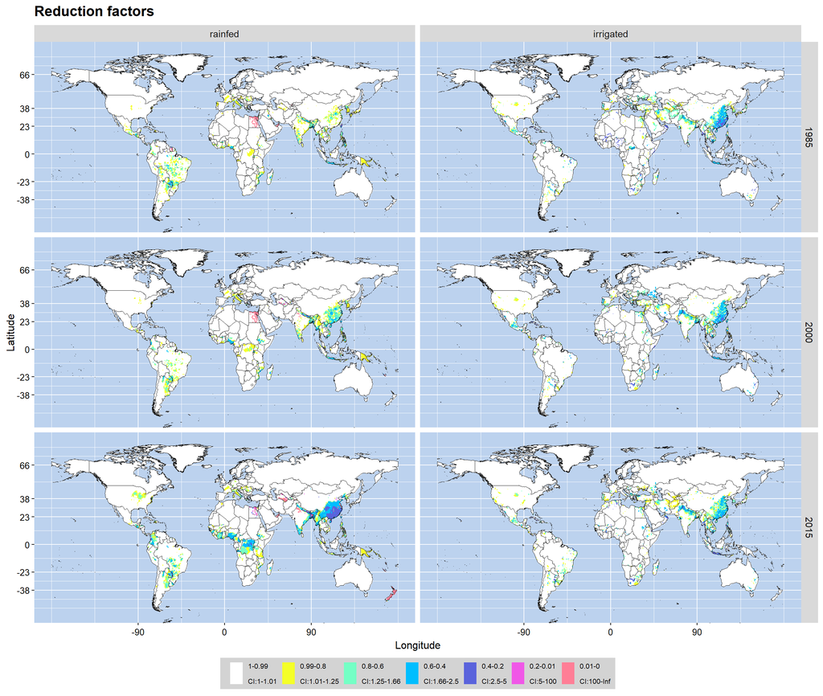

```r
#factor_1b[factor_1b == 0] <- 1  # factors

factor_1b[factor_1b > 1] <- 1 # if the factor is greater han 1 we don't apply it

p<- luplot::plotmap2( toolCoord2Isocell(factor_1b)  ,
  legend_range = c(0, 1 ) ,
  legend_discrete =T,
  legend_breaks= c(0.01, seq(0.2,0.8,0.2), 0.99),
  title = "Reduction factors" )


# change the appearance
colors <-  c("#FFFFFF", "#f4ff28","#74ffc5", "#00beff","#5a63dc" , "#f057e7", "#ff7e96")
labels <- c("1-0.99\n\nCI:1-1.01", "0.99-0.8\n\nCI:1.01-1.25", "0.8-0.6\n\nCI:1.25-1.66",
            "0.6-0.4\n\nCI:1.66-2.5", "0.4-0.2\n\nCI:2.5-5", "0.2-0.01\n\nCI:5-100",
            "0.01-0 \n\nCI:100-Inf")
p +
  scale_fill_manual(values = colors ,
                    labels = labels
                        , name =NULL ) +
  theme(legend.key.size = unit(0.5, 'cm'), legend.key.height = unit(0.5, 'cm'))+
  theme(legend.position="bottom", legend.direction = "horizontal", legend.text.align = 0,
        legend.background = element_rect(fill="lightgray"), legend.text=element_text(size=8))+
  guides(fill=guide_legend(nrow=1))
```

The reduction factors are very much dependent on the year and the region.

### Advantage of 1b: Consitency with HYDE

One advantage of method 1b is that in the result, the sums of irrigated and rainfed groups will be consistent to the physical area coming from HYDE data: In the cells where the comparison of harvested and physical areas implies complete use of the cropland (no fallow), the sum of the resulting rainfed (resp . irrigated) crop physical areas will be equal to HYDE total rainfed (resp. irrigated) physical area.

This will not be the case for method 1a. Here the physical areas for the different crops will not necessarily sum up to the totals from HYDE in cases where they should (i.e. no fallow land). In this sense the physical totals of 1a will be erroneous.

First confirm that 1b is consistent with HYDE data in “complete landuse” cells.

```r
fullLanduse <- harvestedAreaTotal >= physicalArea

physicalSum_1a <- dimSums(physicalOut_1a, dim= "crop")
physicalSum_1b <- dimSums(physicalOut_1b, dim= "crop")

error1b <-  ifelse( fullLanduse, physicalSum_1b -physicalArea, NaN)
summary( error1b )
```

```
##    Min. 1st Qu.  Median    Mean 3rd Qu.    Max.    NA's
##       0       0       0       0       0       0  116306
```

```r
error1a <- ifelse( fullLanduse, physicalSum_1a -physicalArea, NaN)
summary( error1a )
```

```
##    Min. 1st Qu.  Median    Mean 3rd Qu.    Max.    NA's
##   -0.07    0.00    0.00    0.00    0.00    0.10  116306
```

To look into the details, see the below plot that displays the relative error of irrigated and rainfed phyiscal total with 1a.

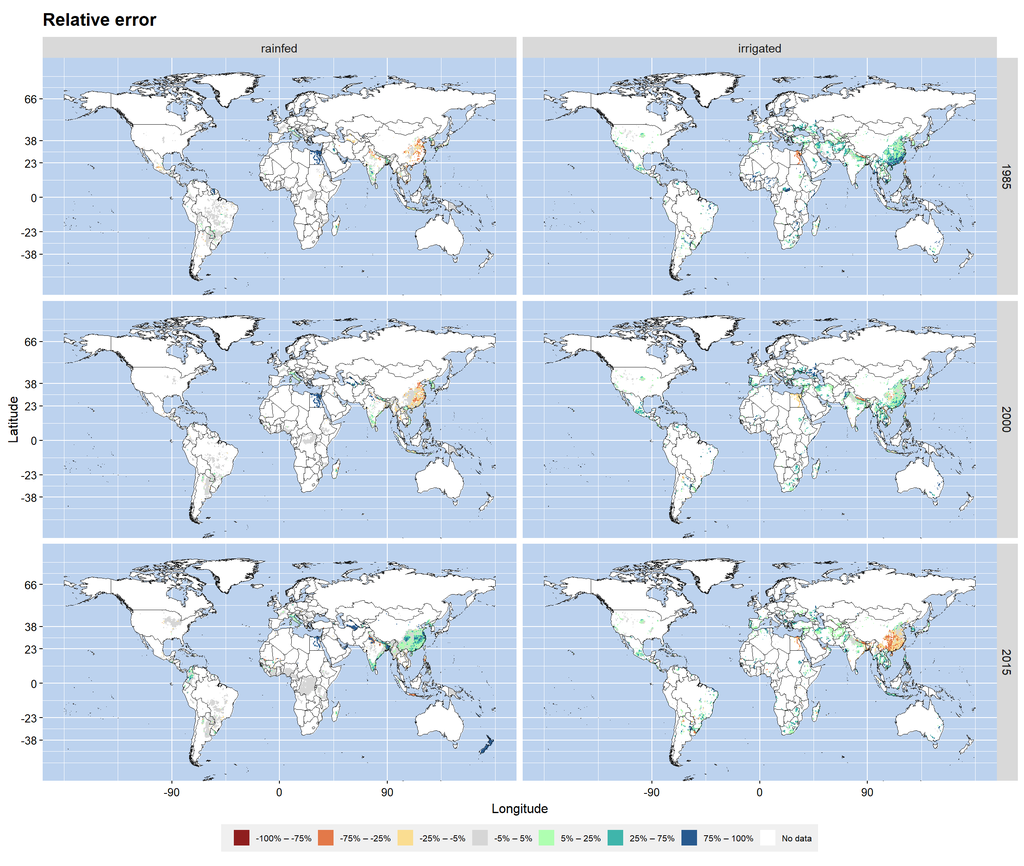

```r
p<- luplot::plotmap2( toolCoord2Isocell(
  error1a/  physicalArea )  ,
  legend_range = c(-1,1 ) ,
  legend_discrete = T, legend_breaks = c(-1,-0.75,-0.25,-0.05,0.05,0.25,0.75,1),
  legendname = "",
  title = "Relative error",
  midpoint=0 )


colors <-  c("2" ="#8F1E1E", "3"= "#E37949","4"="#FADD91", "5"="#D6D6D6" ,"6"="#AFFFB1","7"= "#3FB5AB", "8"="#285A8F", "No data"="white")

labels <- c("2" = "-100% – -75%", "3" = "-75% – -25%",  "4" = "-25% – -5%", "5" = "-5% – 5%",  "6" = "5% – 25%","7" = "25% – 75%", "8"= "75% – 100%",   "No data" = "No data")

p +
  scale_fill_manual(values = colors, name =NULL,  labels =labels ) +
  theme(legend.key.size = unit(0.5, 'cm'), legend.key.height = unit(0.5, 'cm'))+
  theme(legend.position="bottom", legend.direction = "horizontal", legend.text.align = 0,
        legend.background = element_rect(fill="#F0F0F0"), legend.text=element_text(size=8))+
  guides(fill=guide_legend(nrow=1))
```

The interpretation of the figure is: How wrong do we get the totals of physical area for the irrigated and rainfed groups, in the “complete landuse” cells, when deciding to use 1a instead of 1b. Green and blue colors mean we will have to high physical area totals. Yellow and red colors mean we have to little physical area totals.

Sidenote: **In general the over- and underestimation of physical land in 1a looks consistent with the difference of rainfed and irrigated reduction factors displayed in the previous plot. An apparent exception is the difference of reduction factors in Centeral- and West Africa in 2015 where we the data indicated emerging multicropping for the rainfeds but not for the irrigated and still we make no error. This can be explained by noting that very few cells of this region have irrigated land at all.**

### Problem of 1b: “Egypt Issue”

#### Note on how the issue could occure in the toolbox

In the country-level as well as cell-level processing of the toolbox the harvested areas (coming from FAOSTAT, Auquastat and MIRCA2000) are adjusted in order to fulfill a number of consistency constraints together with data from other sources. One of these constraints is that the rainfed (resp. irrigated) harvested area sums cannot be greater than physical rainfed (resp. irrigated) areas from the HYDE data times a multicropping suitability factor. In principle this would ensure that the resulting multicropping factors cannot get unrealistically high.

However, there is one exception to this rule: When rainfed_harvested_area exceeds physical_rainfed times multicropping_suitability, but there is irrigated land that is not already used by irrigated crops, then rainfed crops are not reduced until the excess fills up the remaining room for irrigated harvested area or gets above total irrigated cropland times rainfed multicropping suitability. In other words: “Rainfed crops can be grown on rainfed cropland but also on irrigated cropland that is not already used for irrigated crops.”(Manuscript, p.15)

So ultimately the issue occurs due to a mismatch between harvested area from FAOSTAT, Auquastat and MIRCA2000 and physical cropland from HYDE.

Sebastian explained that a reason for this mismatch could be that some harvested areas are wrongly labeled rainfed, but actually are irrigated: The FAOSTAT data is the most comprehensive source for harvested areas but does not contain a seperation in irrigation systems. To find out which harvested areas of FAOSTAT are irrigated, the irrigation data sources MIRCA2000 and Aquastat are used in the toolbox. The rest of the harvested area will then be labeled rainfed. The problem is that those sources are not as complete as FAOSTAT, so if a crop is missing there it would be wrongly labeled rainfed.

#### Location of the cells

Call “Egypt issue” cells those cells with almost zero physical rainfed but existing harvested rainfed, i.e. cells with extremly high rainfed CIs when choosing 1b.

How many cells are affected?

```r
Egypt_iss  <- (harvestedAreaTotal[,,"rainfed"]>10^-7)&(physicalArea[,,"rainfed"]<10^-15)

percent(mean(Egypt_iss))
```

```
## [1] "0.360%"
```

Where are those cells on a map?

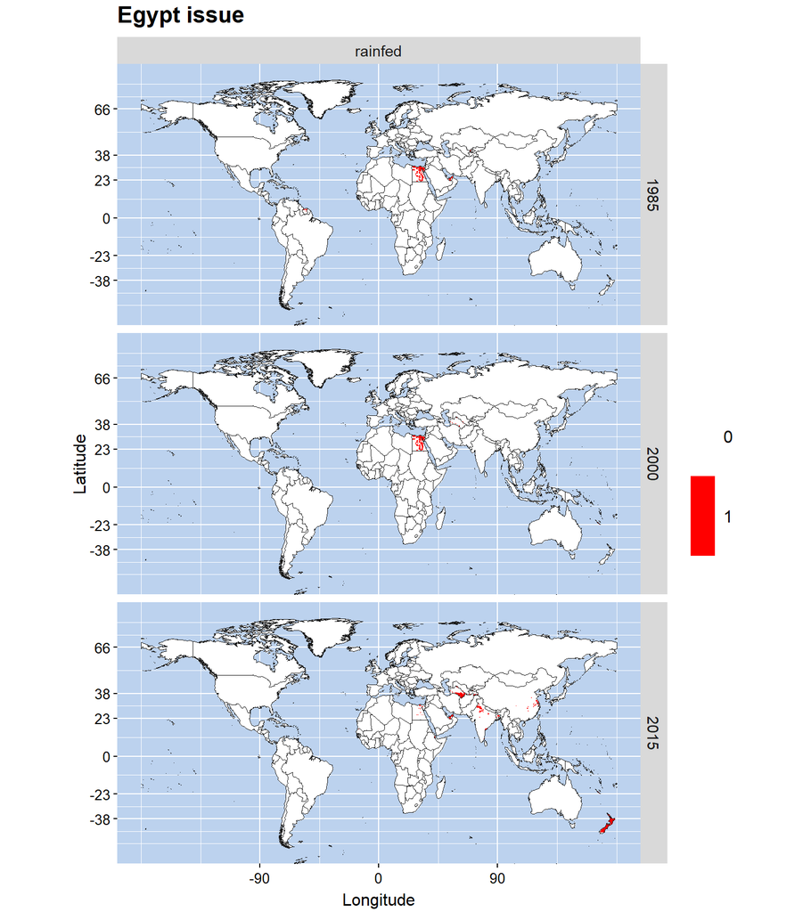

```r
luplot::plotmap2( toolCoord2Isocell(
  Egypt_iss)  ,
  legend_range = c(0,1 ) ,
  midcol = "white",
  highcol = "white",
  lowcol = "red",
  legend_discrete = T,
  legendname = "",
  title = "Egypt issue",
  midpoint=0 )
```

##### Note on irrigation in Egypt

“The area of agricultural land in Egypt is confined to the Nile Valley and delta, with a few oases and some arable land in Sinai. The total cultivated area is 7.2 million feddans (1 feddan = 0.42 ha), representing only 3 percent of the total land area. The entire crop area is irrigated, except for some rain-fed areas on the Mediterranean coast.” (fao.org)

https://www.fao.org/3/v9978e/v9978e0e.htm

##### Note on irrigation in Turkmenistan

“Agriculture in the newly independent republics of the former Soviet Centeral Asia is almost entirely dependent on irrigation” (Nesbitt, 2000)

https://www.researchgate.net/publication/234002869_Irrigation_agriculture_in_Central_Asia_A_longterm_perspective_from_Turkmenistan

“Because of the arid climate, irrigation is necessary for nearly all cultivated land.” (Wikipedia, Agriculture in Turkmenistan) https://en.wikipedia.org/wiki/Agriculture_in_Turkmenistan

##### Note on irrigation in UAE

“In fact, all the agricultural land in the UAE are 100% irrigated.” (Shahin, 2014)

https://www.researchgate.net/profile/Suzan-Shahin/publication/271375392_Food_security_in_the_United_Arab_Emirates_UAE_The_great_competition_between_the_agricultural_and_forestry_sector_on_irrigation_resources/links/54c661600cf2911c7a58c46d/Food-security-in-the-United-Arab-Emirates-UAE-The-great-competition-between-the-agricultural-and-forestry-sector-on-irrigation-resources.pdf

These sources support the HYDE data and suggest that the rainfed harvested areas in these countries are not correct. Possibly they are just wrongly labeled as described above. One could argue that zeroing these apparently wrong harvested areas, as would happen in 1b, is be the best way to deal with them. On the other hand, if then the incorrect harvested areas are used to compute the CIs, we would get extremly high rainfed CIs in these areas.

#### Which rainfed crops are growing in Egypt according to our data?

See the total harvested area of all rainfed crops in the inconsitent Egypt cells of 1985 (in Mha)

```r
harvestedArea[Egypt_iss[,"y1985",],"y1985","rainfed" ]["EGY",,] %>%
  dimSums(dim=1) %>%
  as.data.frame() %>%
  select("Data2","Value") %>%
  arrange(-Value)
```

```
##        Data2        Value
## 1      foddr 8.125793e-01
## 2       maiz 2.172560e-01
## 3   puls_pro 6.379340e-02
## 4     others 5.754447e-02
## 5    soybean 4.538245e-02
## 6       trce 2.216832e-02
## 7       tece 7.762745e-03
## 8     potato 1.630502e-03
## 9   rice_pro 3.999476e-04
## 10 sugr_cane 4.296138e-05
## 11  rapeseed 0.000000e+00
## 12 groundnut 0.000000e+00
## 13 sunflower 0.000000e+00
## 14   oilpalm 0.000000e+00
## 15 cassav_sp 0.000000e+00
## 16 sugr_beet 0.000000e+00
## 17 cottn_pro 0.000000e+00
```

…of 2000

```r
harvestedArea[Egypt_iss[,"y2000",],"y2000","rainfed" ]["EGY",,] %>%
  dimSums(dim=1) %>%
  as.data.frame() %>%
  select("Data2","Value") %>%
  arrange(-Value)
```

```
##        Data2        Value
## 1      foddr 1.071669e+00
## 2     others 8.480801e-02
## 3       tece 1.875644e-02
## 4       maiz 1.507460e-02
## 5   rice_pro 9.190582e-03
## 6       trce 6.441757e-03
## 7  groundnut 1.087834e-03
## 8  cassav_sp 2.272352e-19
## 9    soybean 0.000000e+00
## 10  rapeseed 0.000000e+00
## 11 sunflower 0.000000e+00
## 12   oilpalm 0.000000e+00
## 13  puls_pro 0.000000e+00
## 14    potato 0.000000e+00
## 15 sugr_cane 0.000000e+00
## 16 sugr_beet 0.000000e+00
## 17 cottn_pro 0.000000e+00
```

…of 2015

```r
harvestedArea[Egypt_iss[,"y2015",],"y2015","rainfed" ]["EGY",,] %>%
  dimSums(dim=1) %>%
  as.data.frame() %>%
  select("Data2","Value") %>%
  arrange(-Value)
```

```
##        Data2       Value
## 1      foddr 0.307315145
## 2       tece 0.047321562
## 3  sugr_beet 0.029583585
## 4       maiz 0.027055016
## 5     potato 0.023756059
## 6     others 0.020618998
## 7   rice_pro 0.019043656
## 8  groundnut 0.003172155
## 9    soybean 0.001960192
## 10 sugr_cane 0.001208778
## 11      trce 0.000000000
## 12  rapeseed 0.000000000
## 13 sunflower 0.000000000
## 14   oilpalm 0.000000000
## 15  puls_pro 0.000000000
## 16 cassav_sp 0.000000000
## 17 cottn_pro 0.000000000
```

The main culprit seems to be allegedly rainfed fodder.